# Session 5

## Learning goals

- Sourcing files
- Histograms - are data normally distributed?
- Transforming data
- Generate random data
- Saving plots

One of the more important assumptions in an ANOVA is that the data are normally distributed. In the last session we did a few ANOVAs without checking. Were the Shannon diversity values normally distributed? How would we know? We could generate some histograms using `hist` and compare the observed distributions to what we’d expect if the data were normally distributed.

```r
source("code/baxter.R")
```

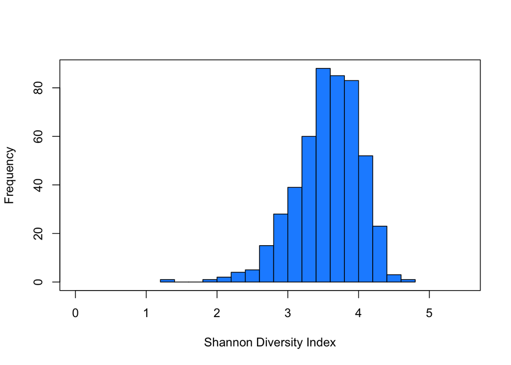

```r
meta_alpha <- get_meta_alpha()

hist(meta_alpha$shannon, xlab="Shannon Diversity Index", col="dodgerblue", main="", breaks=20, xlim=c(0,5.5))
box()
```

> A quick reminder that if you weren’t able to make your own version of `code/baxter.R`, but want to move on before fixing the problems with your file, you can use `source("code/baxter_soln.R")` instead.

Can we split the data so that we can make a histogram for each diagnosis group? Make `normal_shannon`, `adenoma_shannon`, and `cancer_shannon` variables and then go ahead and make a histogram for each variable.

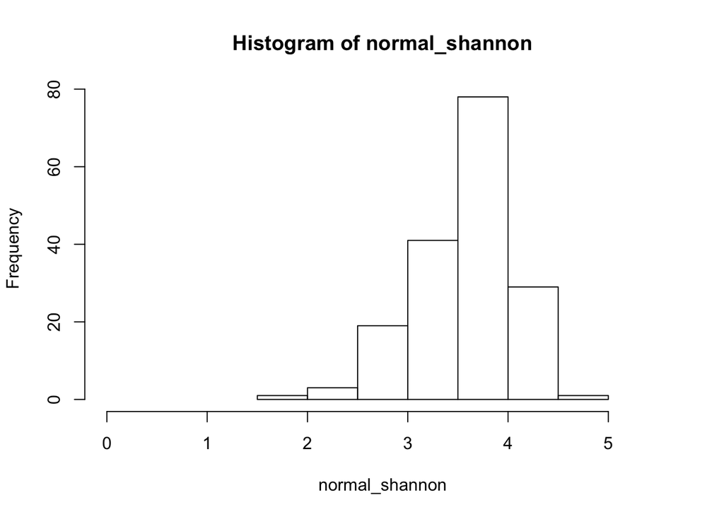

```r
normal_shannon <- meta_alpha[meta_alpha$dx == "normal", "shannon"]
adenoma_shannon <- meta_alpha[meta_alpha$dx == "adenoma", "shannon"]
cancer_shannon <- meta_alpha[meta_alpha$dx == "cancer", "shannon"]

hist(normal_shannon, xlim=c(0,5.5))
```

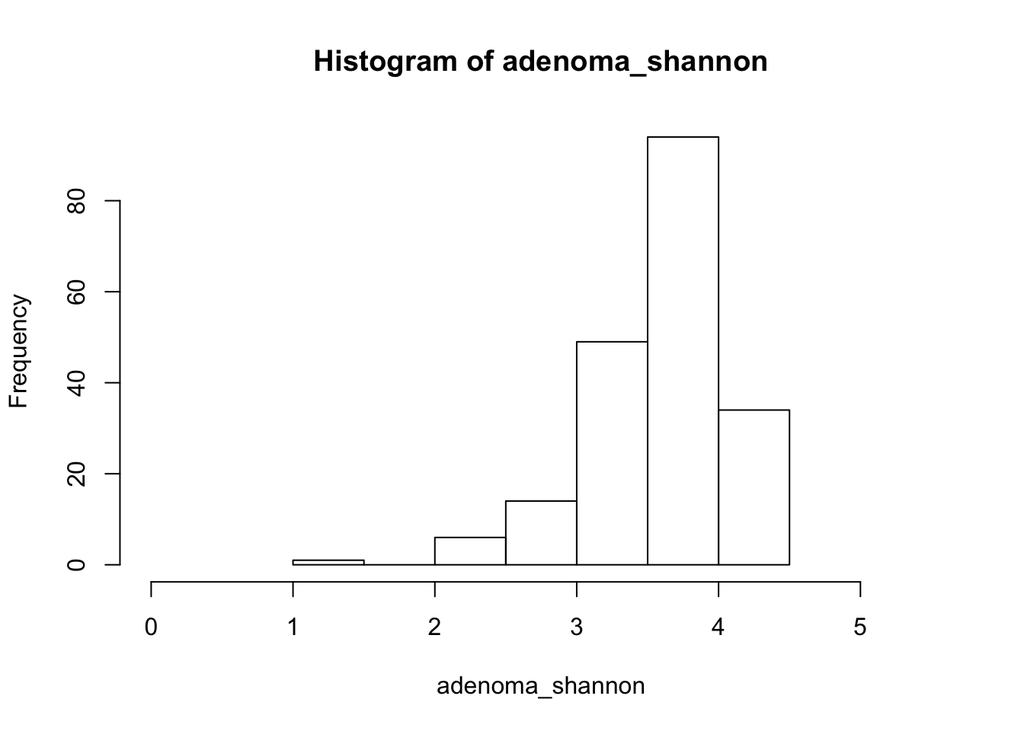

```r
hist(adenoma_shannon, xlim=c(0,5.5))
```

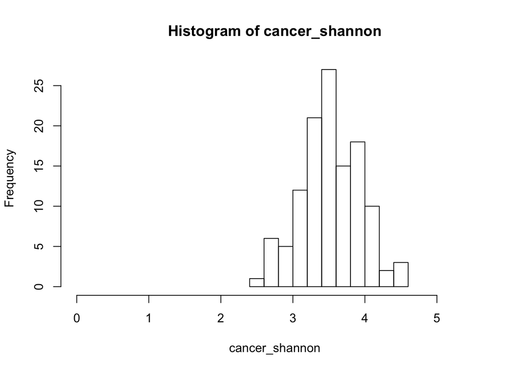

```r
hist(cancer_shannon, xlim=c(0,5.5))
```

What do you notice about each plot? Do they look normal? Are you able to compare the histograms to each other very easily? One problem with comparing the different histograms is that the size of the bins varies by diagnosis group. In the `hist` function we can set the `breaks` argument either to a number to indicate the number of breaks (we did this above), or we can give a vector to indicate the position of the breaks to make the bins.

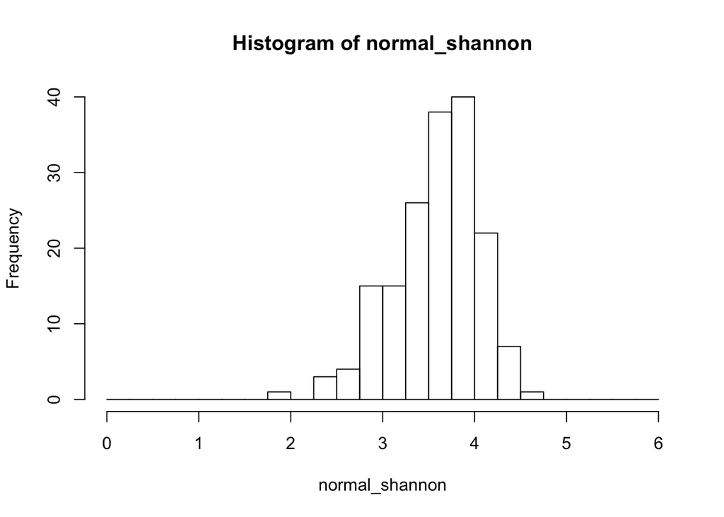

```r
my_breaks <- seq(0,6,0.25)
hist(normal_shannon, xlim=c(0,6), breaks=my_breaks)
```

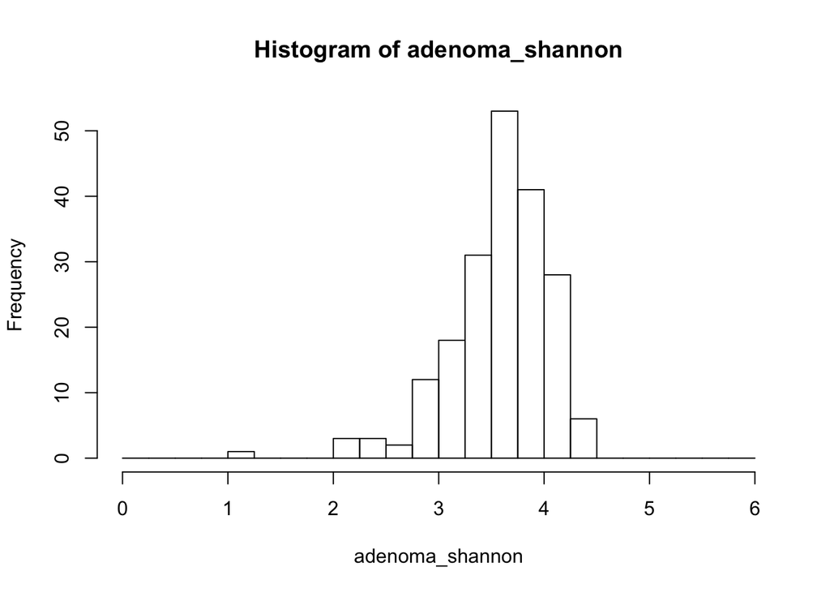

```r
hist(adenoma_shannon, xlim=c(0,6), breaks=my_breaks)
```

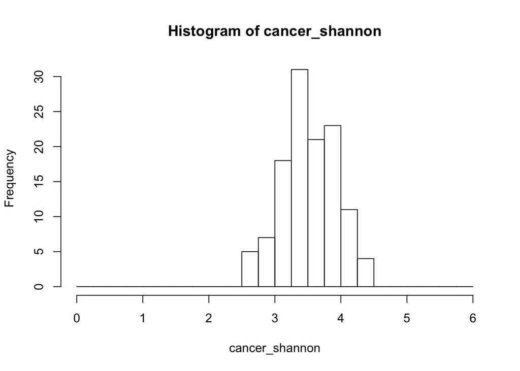

```r
hist(cancer_shannon, xlim=c(0,6), breaks=my_breaks)
```

The first thing we would like to do is determine whether the distributions are normally distributed. There are several ways to do this. For demonstration purposes, we’ll work with the normal colon data. Let’s start by getting the mean and standard deviation for our samples

```r
normal_mean <- mean(normal_shannon)
normal_sd <- sd(normal_shannon)
```

If our data were normally distributed then their distribution should look like data that had been drawn from a normal distribution with a mean of 3.5759032 and a standard deviation 0.4669267. We can simulate re-sampling 172 samples using the `rnorm` function in R and we can plot the data using `hist`

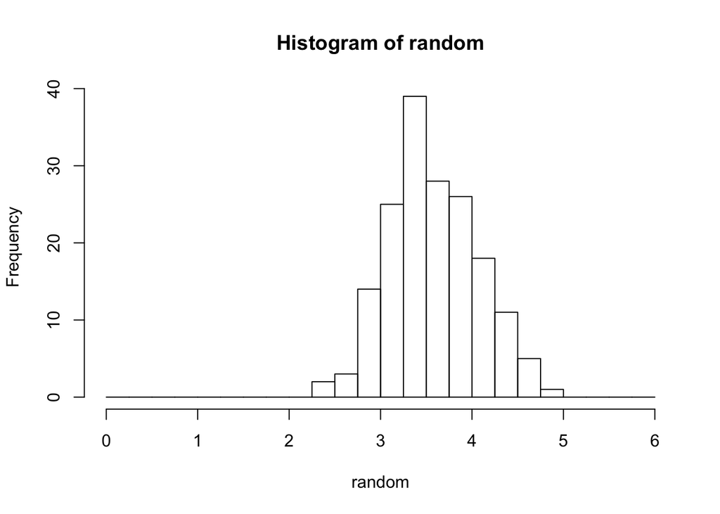

```r
random <- rnorm(n=length(normal_shannon), mean=normal_mean, sd=normal_sd)
hist(random, breaks=my_breaks)
```

It would be great to plot the histograms of `normal_shannon` and `random` on top of each other. We could plot the barplot histograms on top of each other, but this makes it hard to see what’s going on.

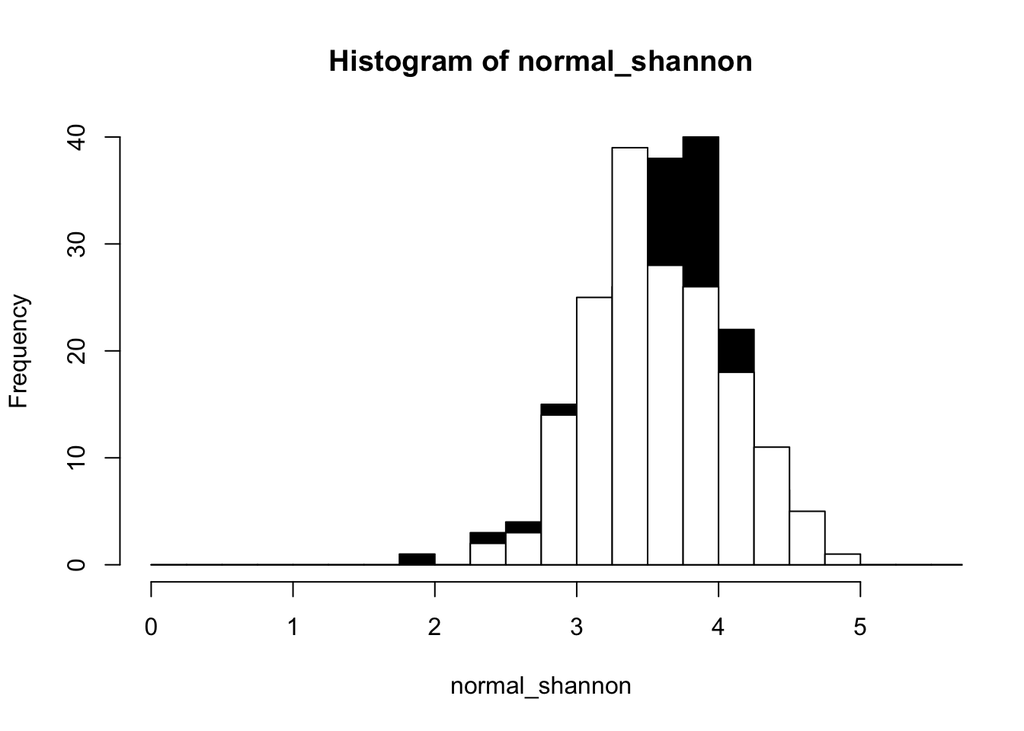

```r
hist(normal_shannon, xlim=c(0,5.5), breaks=my_breaks, col="black")
hist(random, breaks=my_breaks, add=T, col="white")
```

Instead, let’s represent the distributions as lines by generating density plots using the `density` and `plot` functions.

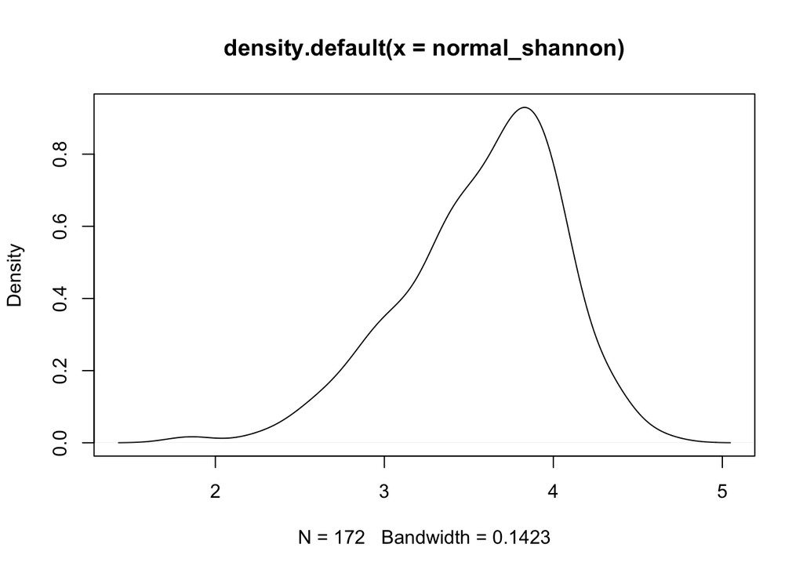

```r
plot(density(normal_shannon), col="black")
```

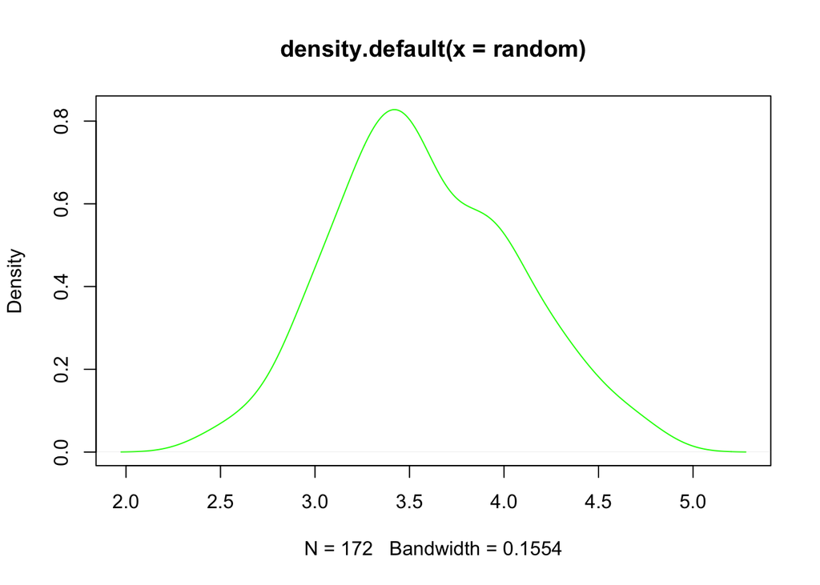

```r
plot(density(random), col="green")
```

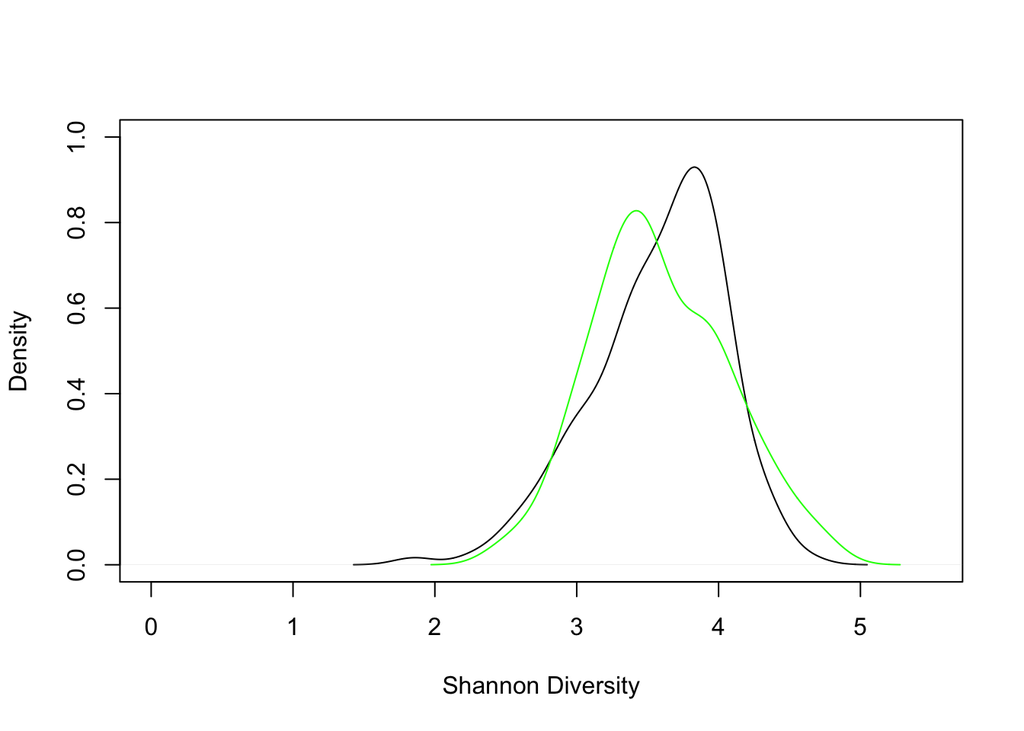

```r
plot(density(normal_shannon), col="black", type="l", xlim=c(0,5.5), ylim=c(0,1.0), xlab="Shannon Diversity", main="")
points(density(random), col="green", type="l")
```

You can see that we used the `type="l"` argument to generate lines. The default is to plot points (`type="p"`) as we did for the scatter plots in earlier sessions. These lines are a bit thin. To thicken them, we can use the `lwd` argument. We’ll plot the histograms with different line thicknesses. Play around with using different values for `lwd` and see what you like.

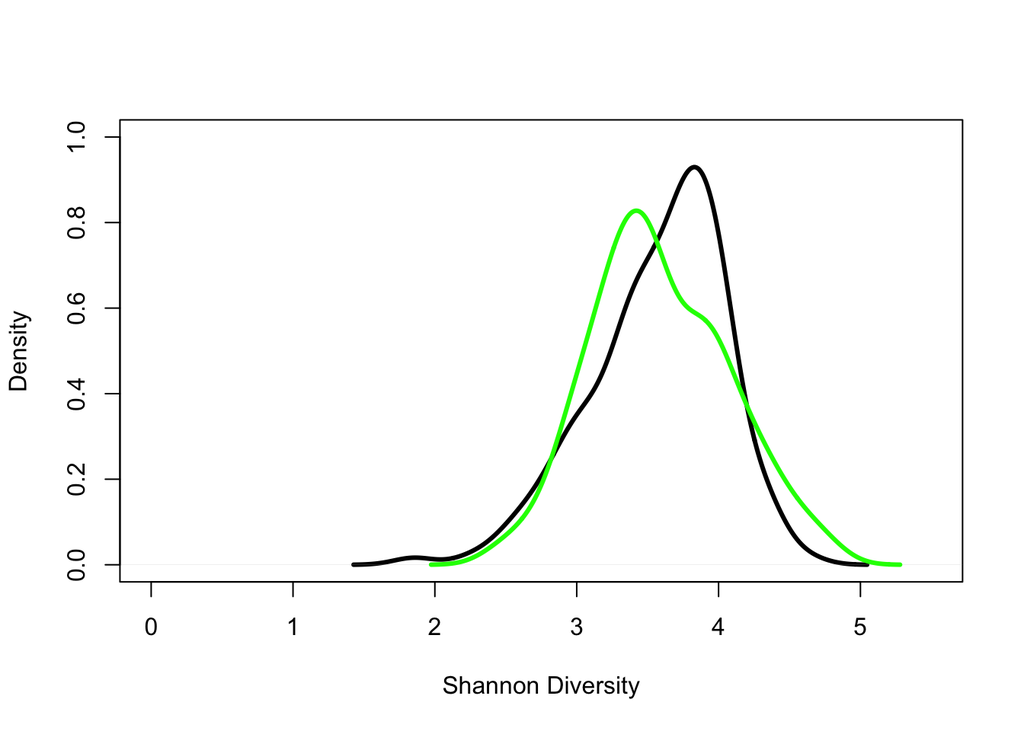

```r
plot(density(normal_shannon), col="black", type="l", lwd=3, xlim=c(0,5.5), ylim=c(0,1.0), xlab="Shannon Diversity", main="")
points(density(random), col="green", lwd=3, type="l")
```

Now we have overlapping histograms for the random and observed data. For the normal colon dataset the distributions look pretty good. If you re-run the series of commands that generated this plot a few times, you’ll find that the shape of the random curve changes each time.

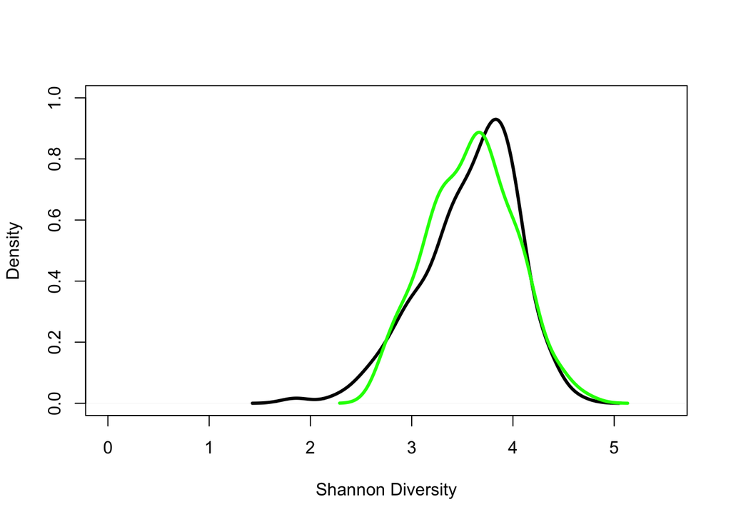

```r
random <- rnorm(n=length(normal_shannon), mean=normal_mean, sd=normal_sd)
plot(density(normal_shannon), col="black", type="l", lwd=3, xlim=c(0,5.5), ylim=c(0,1.0), xlab="Shannon Diversity", main="")
points(density(random), col="green", lwd=3, type="l")
```

To make the plot more reproducible, we could use the `set.seed` function where we give the function a number as an argument. R will then use this value as the seed when it goes to generate a random number. Run the following a few times and see that the curve doesn’t change

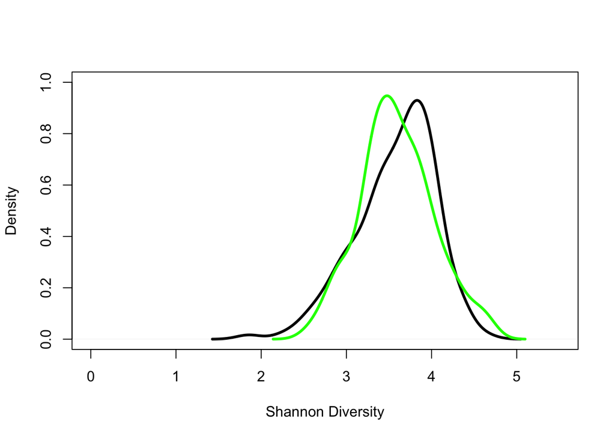

```r
set.seed(1)
random <- rnorm(n=length(normal_shannon), mean=normal_mean, sd=normal_sd)
plot(density(normal_shannon), col="black", type="l", lwd=3, xlim=c(0,5.5), ylim=c(0,1.0), xlab="Shannon Diversity", main="")
points(density(random), col="green", lwd=3, type="l")
```

For this type of analysis, using `rnorm` really isn’t what we want to use. Instead, we should use the `dnorm` function. This will give us the curve that we would expect if we generated thousands of random distributions and averaged them. The `dnorm` function takes the mean and standard deviation for the distribution and the value where we want to calculate the density. We’ll create a vector that goes from 0 to 5.5 in steps of 0.1 and then plot that on top of our `normal_shannon` density plot.

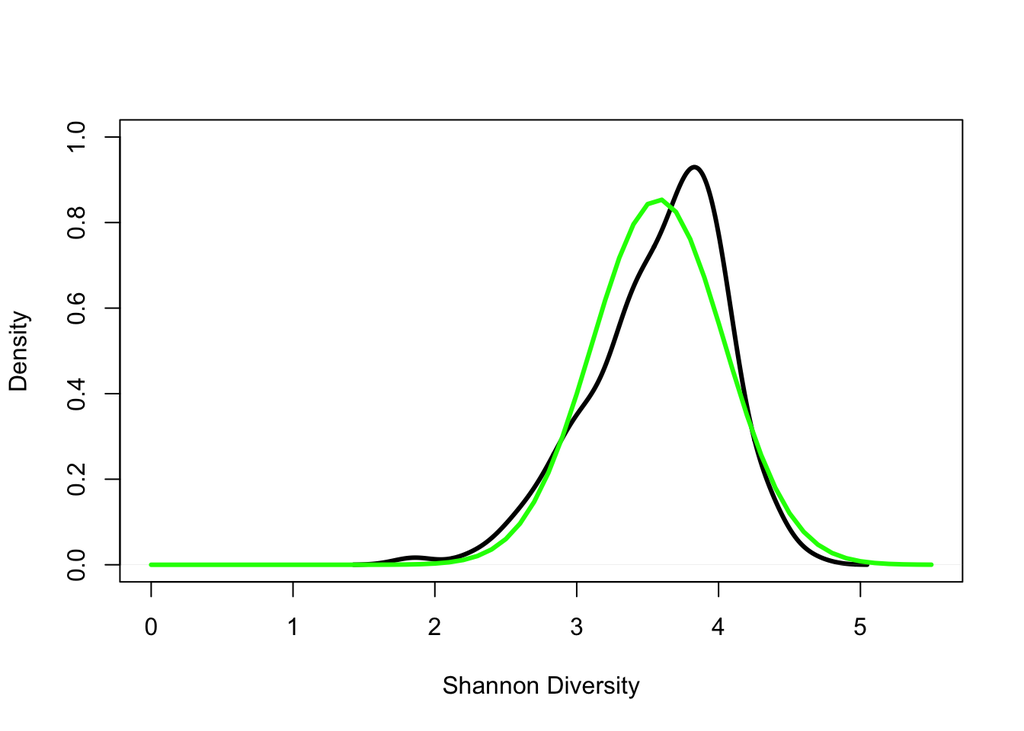

```r
plot(density(normal_shannon), col="black", type="l", lwd=3, xlim=c(0,5.5), ylim=c(0,1.0), xlab="Shannon Diversity", main="")

normal_range <- seq(from=0, to=5.5, by=0.1)
random_density <- dnorm(normal_range, mean=normal_mean, sd=normal_sd)
points(random_density~normal_range, type="l", col="green", lwd=3)
```

That’s not too bad. Our data seems a bit skewed to the right relative to the truly normally distributed data. There’s a more sophisticated and easier way to assess the normality of our data. We can do that by generating a qqplot using the `qqnorm` function. This plots the quantiles our observed data relative to what we’d expect relative to truly normal data. If our data are normally distributed, then we’d expect a straight line.

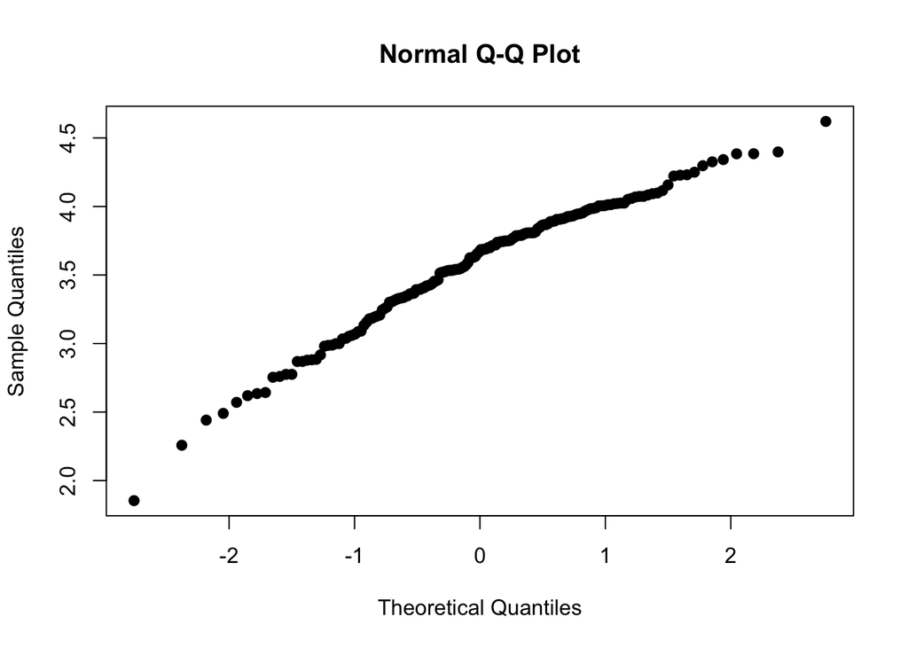

```r
qqnorm(normal_shannon, col="black", pch=19)
```

Again, this looks pretty good. We could try to transform the data various ways to see if the line can get straighter.

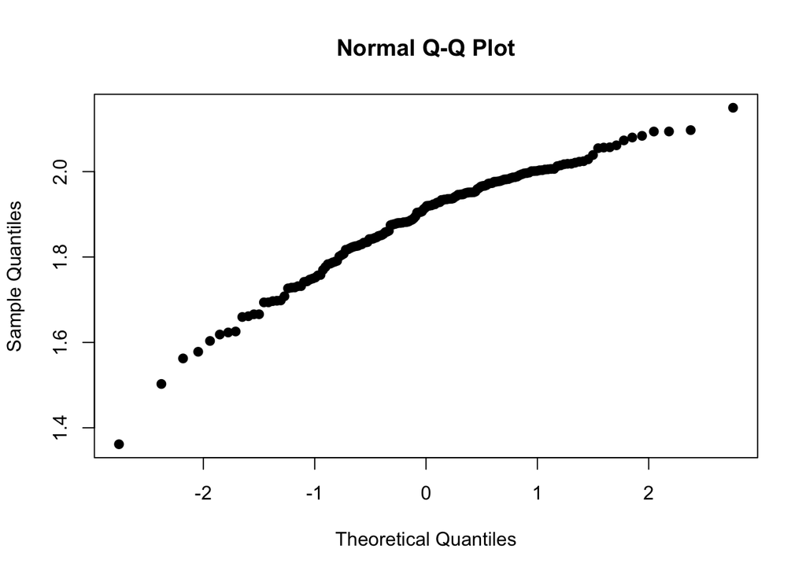

```r
qqnorm(normal_shannon^0.5, col="black", pch=19)
```

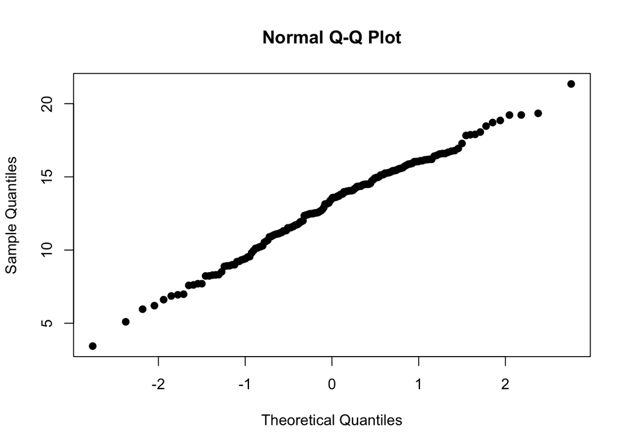

```r
qqnorm(normal_shannon^2, col="black", pch=19)
```

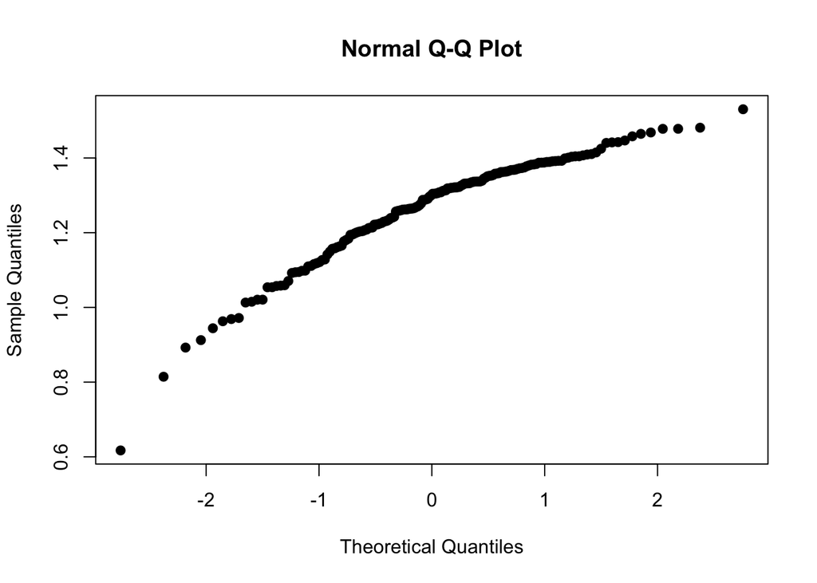

```r
qqnorm(log(normal_shannon), col="black", pch=19)
```

Which of these do you think looks better? Squaring the `normal_shannon` data appears to give the most normally distributed data.

#### Activity 1

Replicate the density and QQ plots we generated for the patients with normal colons to assess the normality of the patients with adenomas and cancer.

#### Activity 2

We’ve compared the distribution of our observed Shannon diversity values to those we’d expect if the data were normally distributed on the same plots. Can you plot the observed distributions for the normal, adenoma, and cancer samples on the same plot?

For this last plot we need a legend so that it’s clear what category each set of lines corresponds to. By now you should be able to largely rough in the syntax for the legend.

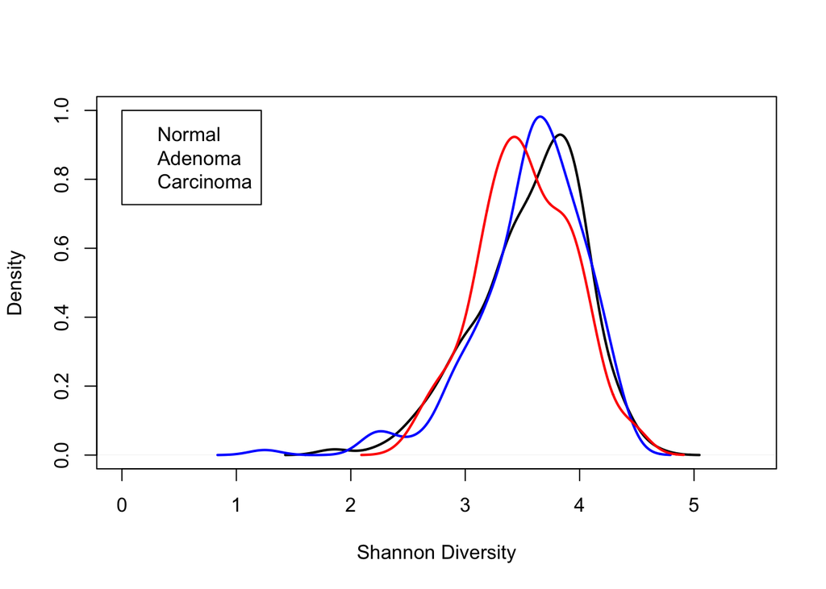

```r
plot(density(normal_shannon), col="black", type="l", lwd=2, xlim=c(0,5.5), ylim=c(0,1.0), xlab="Shannon Diversity", main="")
points(density(adenoma_shannon), col="blue", type="l", lwd=2)
points(density(cancer_shannon), col="red", type="l", lwd=2)
legend(x=0, y=1.0, legend=c("Normal", "Adenoma", "Carcinoma"), col=c("black", "blue", "red"))
```

To generate the lines in the legend, we can add the `lwd` argument

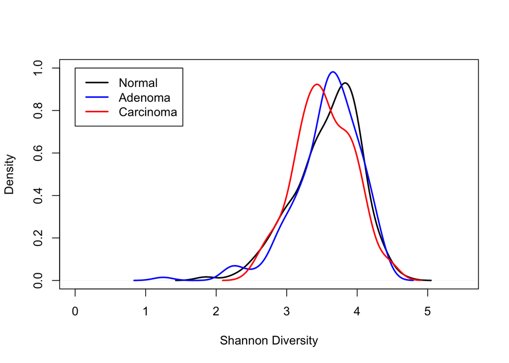

```r
plot(density(normal_shannon), col="black", type="l", lwd=2, xlim=c(0,5.5), ylim=c(0,1.0), xlab="Shannon Diversity", main="")
points(density(adenoma_shannon), col="blue", type="l", lwd=2)
points(density(cancer_shannon), col="red", type="l", lwd=2)

legend(x=0, y=1.0, legend=c("Normal", "Adenoma", "Carcinoma"), col=c("black", "blue", "red"), lwd=2)
```

#### Activity 3

Re-run the ANOVAs that we ran in the previous session using the appropriately transformed data. Note that they all need the same transformation (i.e. you can’t square the values for one treatment and not another). Did the P-values change?

#### Activity 4

We’ve been generating some nice plots along the way, but we’ve never saved them. For the sake of organization, create a folder called “figures”. We will be saving our plots to this folder. In RStudio you can save your plots in the lower right window. From the console window there are several functions we can use to save our plots. From R you can save a plot as a “pdf”, “png”, “jpeg”, “tiff”, or “bmp” file using a similar syntax.

```r
png(filename="figures/bmi_density.png")

plot(density(normal_bmi, na.rm=T), col="black", type="l", lwd=2, xlab="BMI", main="", xlim=c(0,70), ylim=c(0,0.1))
points(density(adenoma_bmi, na.rm=T), col="blue", type="l", lwd=2)
points(density(cancer_bmi, na.rm=T), col="red", type="l", lwd=2)

legend(x=50, y=0.1, legend=c("Normal", "Adenoma", "Carcinoma"), col=c("black", "blue", "red"), lwd=2)

dev.off()
```

Instead of plotting the figure to the screen, the `png` function will plot the data to a file of that format. You can create a figure of any format you want using that format as the function name. Each of these functions will allow you to set a variety of arguments that will effect the size and quality of the figure. You can set the `width` and `height` arguments using values that have `units` of “px”, “cm”, or “in”. You can also set the `pointsize` of text, and the `res`olution in units of pixels per inch (ppi).

```r
tiff(filename="figures/bmi_density.tiff", width=3.5, height=3.4, units="in", res=300, pointsize=6)

plot(density(normal_bmi, na.rm=T), col="black", type="l", lwd=2, xlab="BMI", main="", xlim=c(0,70), ylim=c(0,0.1))
points(density(adenoma_bmi, na.rm=T), col="blue", type="l", lwd=2)
points(density(cancer_bmi, na.rm=T), col="red", type="l", lwd=2)

legend(x=50, y=0.1, legend=c("Normal", "Adenoma", "Carcinoma"), col=c("black", "blue", "red"), lwd=2)

dev.off()
```